# Homework 1-Ayşegül Karakuş

## Homework 1

This is my work for homework-1 of IE 582. In this homework, bettings on English Premier League match results are considered. The distributions and statistics of real match results are compared with selected bookmakers bettings.

## Task 1

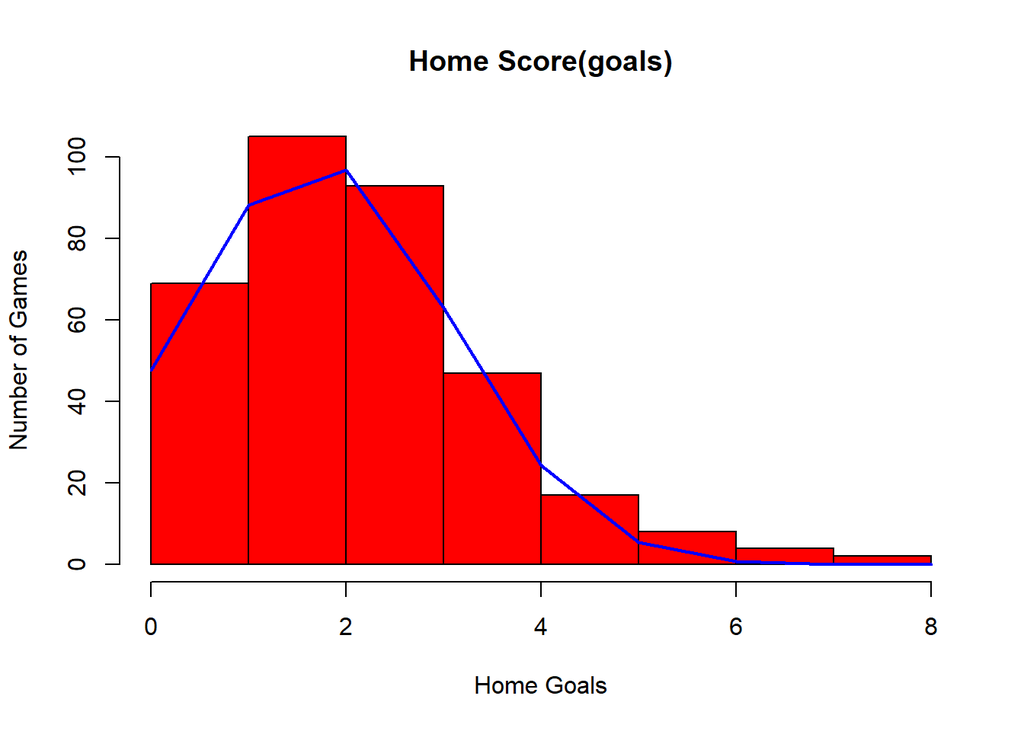

```r
library(data.table)
require(arules)
library(dplyr)
library(tidyverse)

bets=fread("bets.csv",stringsAsFactors = FALSE)
booking=fread("booking.csv",stringsAsFactors = FALSE)
goals=fread("goals.csv",stringsAsFactors = FALSE)
matches=fread("matches.csv",stringsAsFactors = FALSE)
stats=fread("stats.csv",stringsAsFactors = FALSE)

english_matches<-filter(matches, league_id == "148")
complete_english_matches=english_matches[!is.na(english_matches$match_status), ]


h_home<-hist(complete_english_matches$match_hometeam_score,right=F, breaks=8, xlim=c(0,8), xlab="Home Goals", ylab="Number of Games",main="Home Score(goals)", col="red")


home_score<- complete_english_matches$match_hometeam_score
xfit<-seq(min(home_score),max(home_score),length(345))
yfit<-dnorm(xfit,mean=mean(home_score),sd=sd(home_score))
yfit <- yfit*diff(h_home$mids[1:2])*length(home_score)
lines(xfit, yfit, col="blue", lwd=2)
```

The same precedure is also applied for the away goals. Similar to the home goals distributions, the goals away team has Poisson distribution.

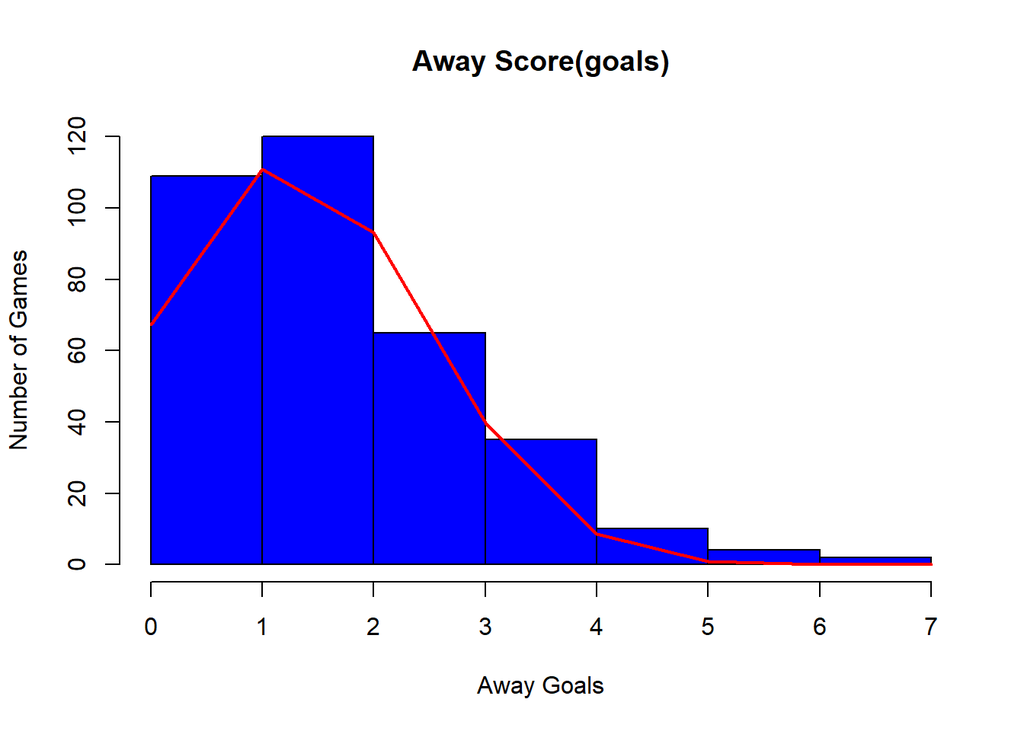

The difference between two Poisson distributions gave normal distribution.

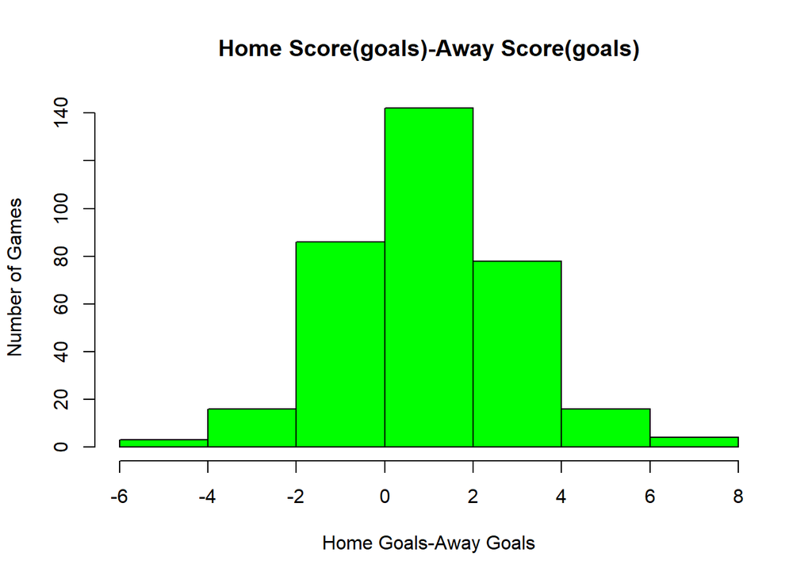

## Task 2

In task 2, the aim is to found out if the bookmakers are good enough to predict the game results. Titanbet, ComeOn, Jetbull, NordicBet and 5Dimes are chosed bookmakers to be analyzed.

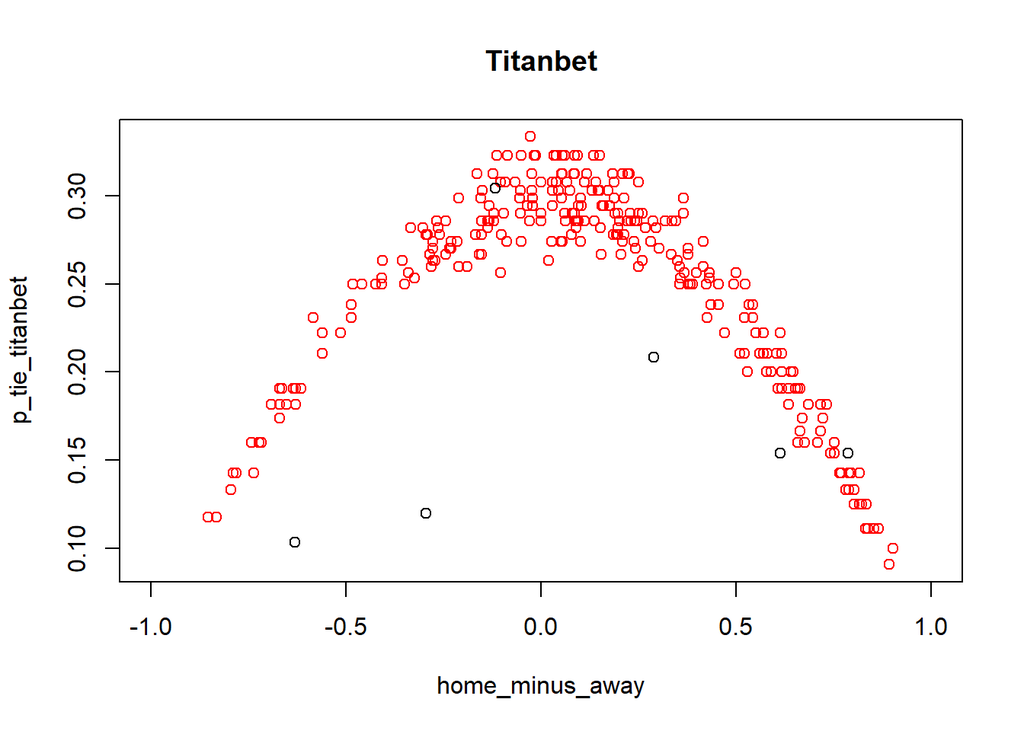

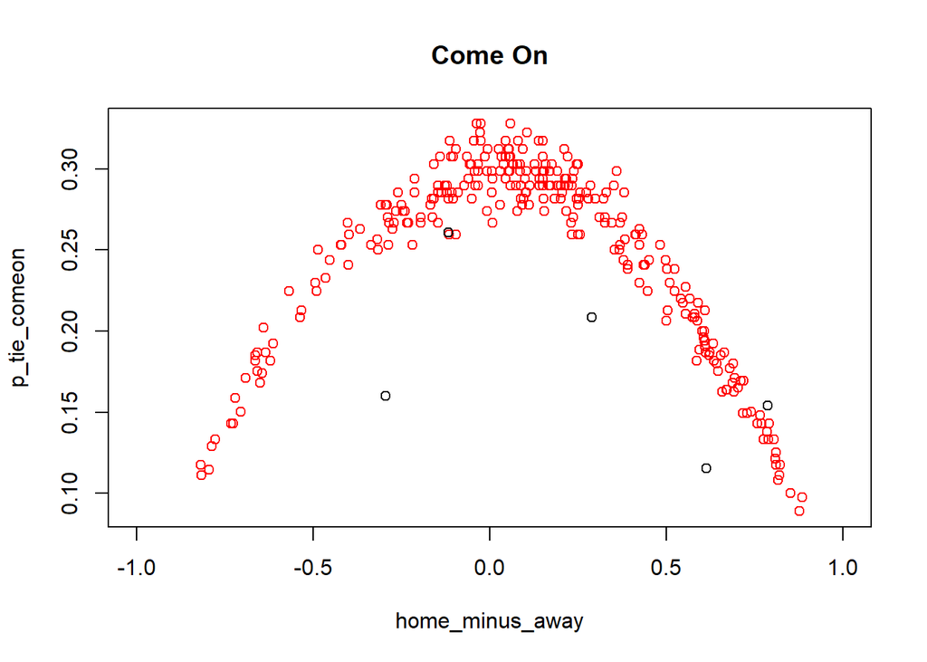

```
##  [-0.818,-0.403]   (-0.403,-0.17]  (-0.17,-0.0389] (-0.0389,0.0483]
##               30               29               30               29
##   (0.0483,0.131]    (0.131,0.215]    (0.215,0.349]    (0.349,0.538]
##               30               30               29               29
##    (0.538,0.668]    (0.668,0.887]
##               29               30
```

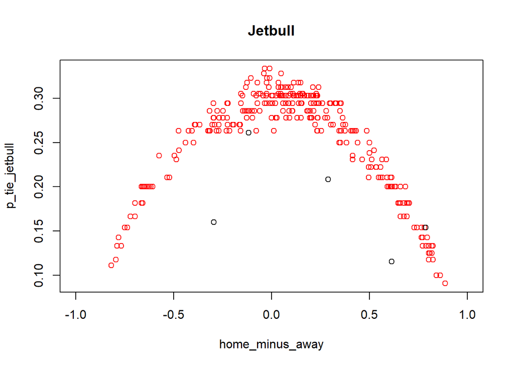

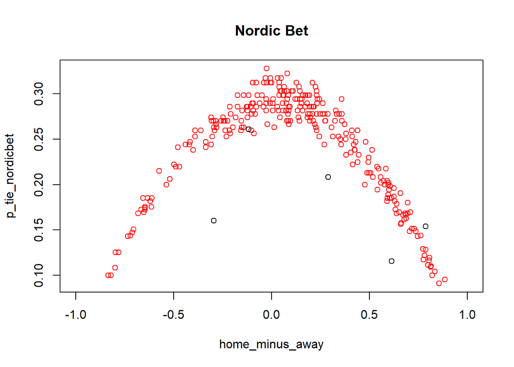

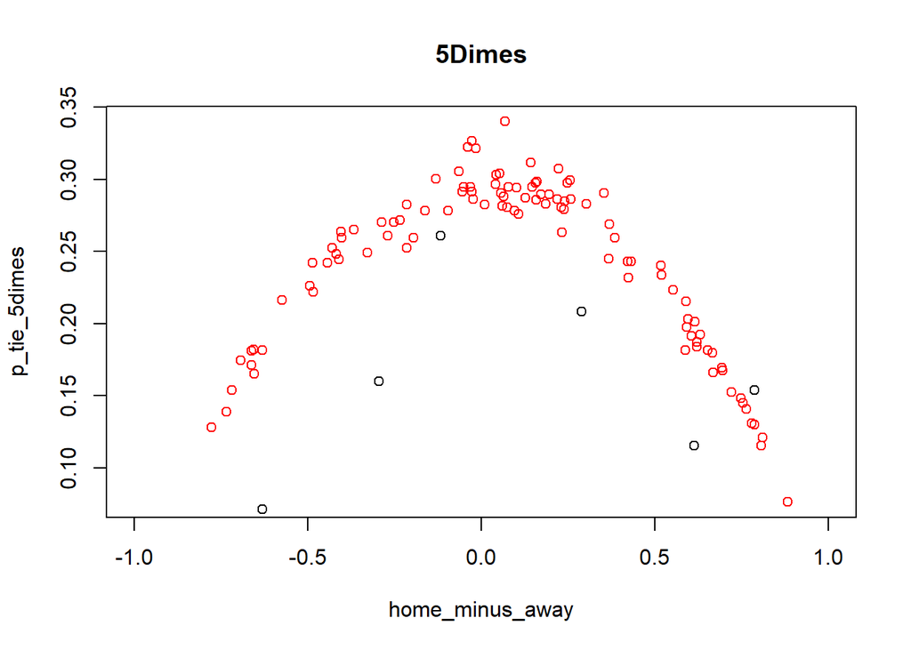

## Task 3

People believe that, the some events in football matches may effect the match results. The events such that, red card in the beginning of the game or the goals in the extra time may create noise. Hence, in this task the results of these matches are removed to reduce the noise in the betting data. The raw data contains 345 English matches and this number is reduced to 283 matches after reduction.

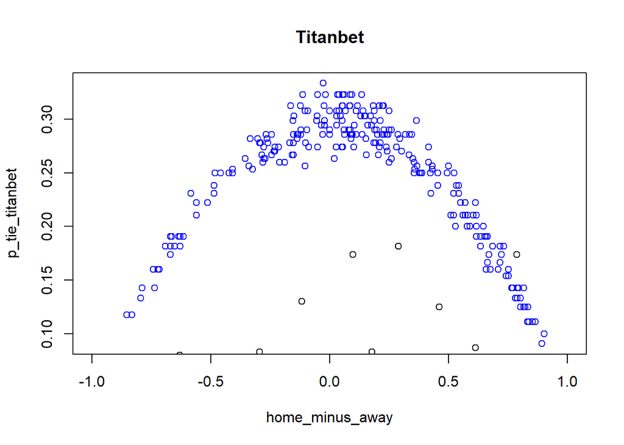

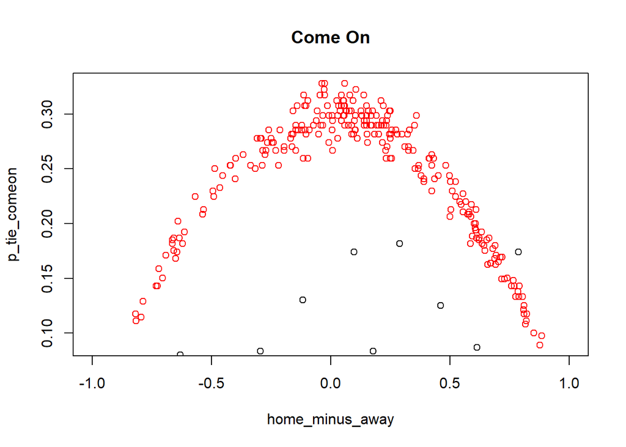

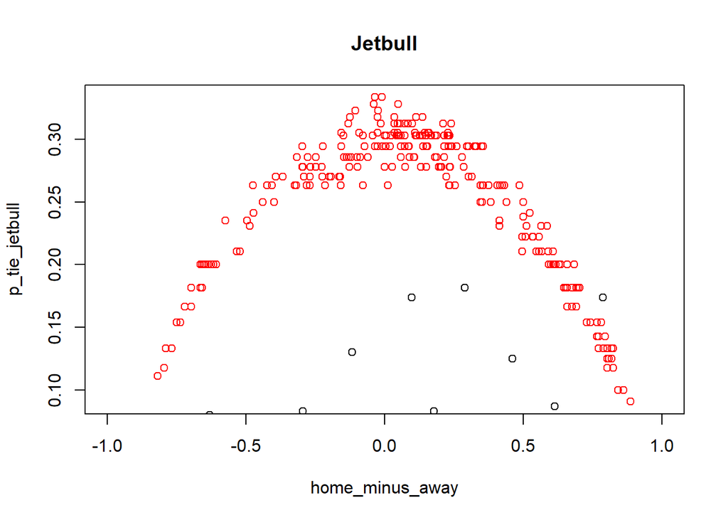

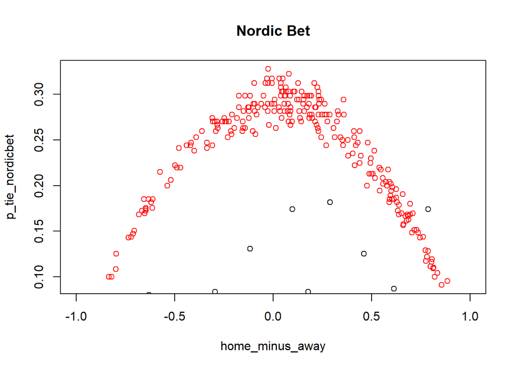

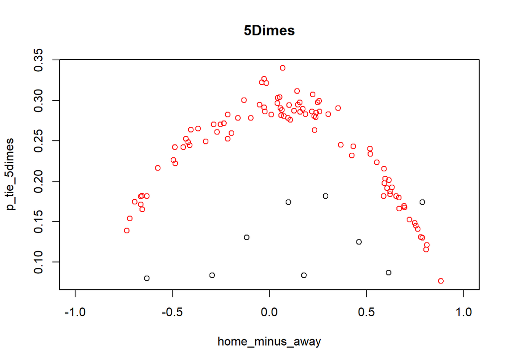

##APPENDIX The full code is given in this part.

```r
library(data.table)
require(arules)
library(dplyr)
library(tidyverse)

bets=fread("bets.csv",stringsAsFactors = FALSE)
booking=fread("booking.csv",stringsAsFactors = FALSE)
goals=fread("goals.csv",stringsAsFactors = FALSE)
matches=fread("matches.csv",stringsAsFactors = FALSE)
stats=fread("stats.csv",stringsAsFactors = FALSE)

#Selecting English Premier League data with league id of 148 and taking only played matches

english_matches<-filter(matches, league_id == "148")
complete_english_matches=english_matches[!is.na(english_matches$match_status), ]

#hist(data) is used with [a,b) interval to plot the histograms
#The home and away goals is found out to have Poisson distribution

max(complete_english_matches$match_hometeam_score)
```

```
## [1] 8
```

```r
max(complete_english_matches$match_awayteam_score)
```

```
## [1] 7
```

```r
max(complete_english_matches$match_hometeam_score-complete_english_matches$match_awayteam_score)
```

```
## [1] 8
```

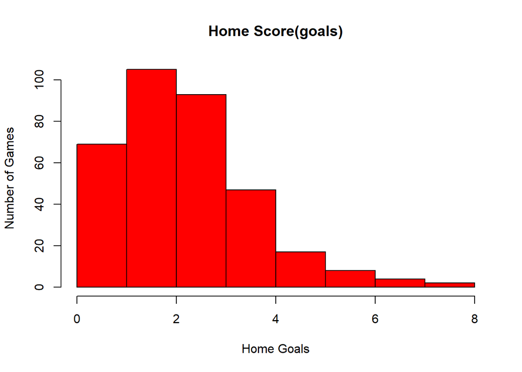

```r
h_home<-hist(complete_english_matches$match_hometeam_score,right=F, breaks=8, xlim=c(0,8), xlab="Home Goals", ylab="Number of Games",main="Home Score(goals)", col="red")
```

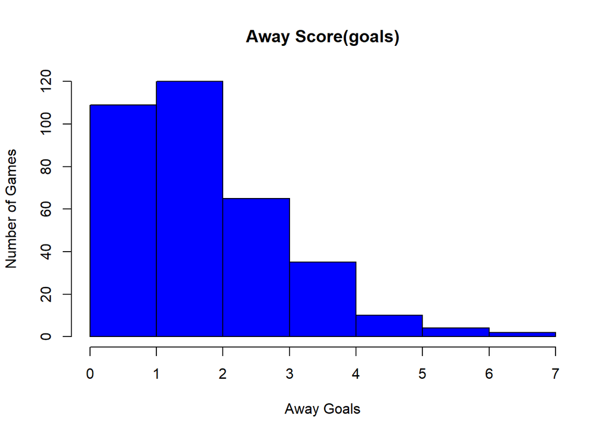

```r
h_away<-hist(complete_english_matches$match_awayteam_score, right=F,  breaks=7, xlim=c(0,7), xlab="Away Goals", ylab="Number of Games",main="Away Score(goals)", col="blue")
```

```r
hist(complete_english_matches$match_hometeam_score-complete_english_matches$match_awayteam_score, right=F,  breaks=7, xlab="Home Goals-Away Goals", ylab="Number of Games",main="Home Score(goals)-Away Score(goals)", col="green")

# Calculating 1st, 2nd and 3rd quantiles for both home and away goals with 2nd quantiles is the expected number of goals the distributions
quantile(complete_english_matches$match_hometeam_score, c(0.25,0.5,0.75))
```

```
## 25% 50% 75%
##   1   1   2
```

```r
quantile(complete_english_matches$match_awayteam_score, c(0.25,0.5,0.75))
```

```
## 25% 50% 75%
##   0   1   2
```

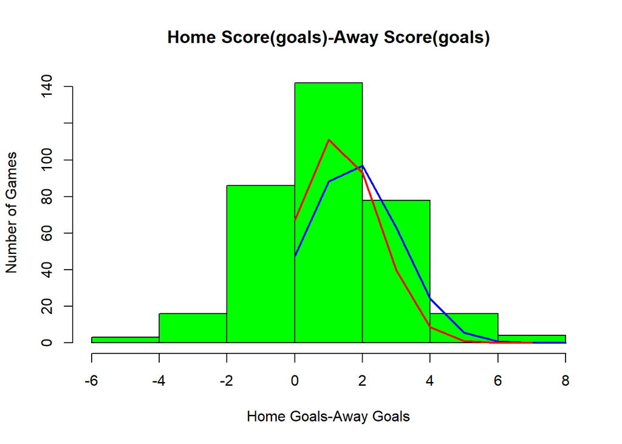

```r
# Add a Normal Curve to the Poisson distribution for hometeam score
home_score<- complete_english_matches$match_hometeam_score
xfit<-seq(min(home_score),max(home_score),length(345))
yfit<-dnorm(xfit,mean=mean(home_score),sd=sd(home_score))
yfit <- yfit*diff(h_home$mids[1:2])*length(home_score)
lines(xfit, yfit, col="blue", lwd=2)

# Add a Normal Curve to the Poisson distribution for awayteam score
away_score<- complete_english_matches$match_awayteam_score
xfit<-seq(min(away_score),max(away_score),length(345))
yfit<-dnorm(xfit,mean=mean(away_score),sd=sd(away_score))
yfit <- yfit*diff(h_away$mids[1:2])*length(away_score)
lines(xfit, yfit, col="red", lwd=2)
```

```r
#############################Task2####################################
# Real match results
complete_english_matches_final<-complete_english_matches %>%  select(match_id,match_hometeam_score, match_awayteam_score)
complete_english_matches_final$english_match_results<-complete_english_matches_final$match_hometeam_score-complete_english_matches_final$match_awayteam_score

#The bets are reduced for only English Premier League with filtering thourough match ids

english_matches_ids <- complete_english_matches$match_id
english_bets=bets[bets$match_id %in% english_matches_ids, ]

head(english_bets)
```

```
##    match_id odd_bookmakers  odd_epoch variable value
## 1:   150842 Interwetten.es 1542450501    odd_1  1.45
## 2:   150842       Titanbet 1542450501    odd_1  1.36
## 3:   150842         ComeOn 1542450501    odd_1  1.39
## 4:   150842        Jetbull 1542450501    odd_1  1.38
## 5:   150842      NordicBet 1542450501    odd_1  1.40
## 6:   150842         5Dimes 1542450501    odd_1  1.41
```

```r
#Titanbet, ComeOn, Jetbull, NordicBet, 5Dimes are chosed bookmakers..

# Bettings from Titanbet for home win, draw and away win
########################################################
home_win_titanbet=filter(english_bets, variable=="odd_1"& odd_bookmakers=="Titanbet")
draw_titanbet=filter(english_bets, variable=="odd_x"& odd_bookmakers=="Titanbet")
away_win_titanbet=filter(english_bets, variable=="odd_2"& odd_bookmakers=="Titanbet")

p_home_titanbet=1/home_win_titanbet$value
p_tie_titanbet=1/draw_titanbet$value
p_away_titanbet=1/away_win_titanbet$value

p_normalized_home_titanbet=(1/home_win_titanbet$value)/(1/home_win_titanbet$value+1/draw_titanbet$value+1/away_win_titanbet$value)
p_normalized_draw_titanbet=(1/draw_titanbet$value)/(1/home_win_titanbet$value+1/draw_titanbet$value+1/away_win_titanbet$value)
p_normalized_away_titanbet=(1/away_win_titanbet$value)/(1/home_win_titanbet$value+1/draw_titanbet$value+1/away_win_titanbet$value)

home_minus_away=p_home_titanbet-p_away_titanbet

titanbet_dt = data.table(home_minus_away, matchids = draw_titanbet$match_id, bins = discretize(home_minus_away,
                                                                                               breaks=10, right=TRUE, left=FALSE)
)

titanbet_dt  = merge(titanbet_dt, complete_english_matches_final, by.x = "matchids", by.y = "match_id")

titanbet_dt= copy(titanbet_dt)[,is_draw := english_match_results == 0]

summary(titanbet_dt$bins)
```

```
##  [-0.853,-0.408]  (-0.408,-0.181] (-0.181,-0.0511] (-0.0511,0.0552]
##               32               28               30               31
##   (0.0552,0.139]    (0.139,0.215]    (0.215,0.365]    (0.365,0.557]
##               28               30               29               30
##    (0.557,0.671]    (0.671,0.902]
##               30               30
```

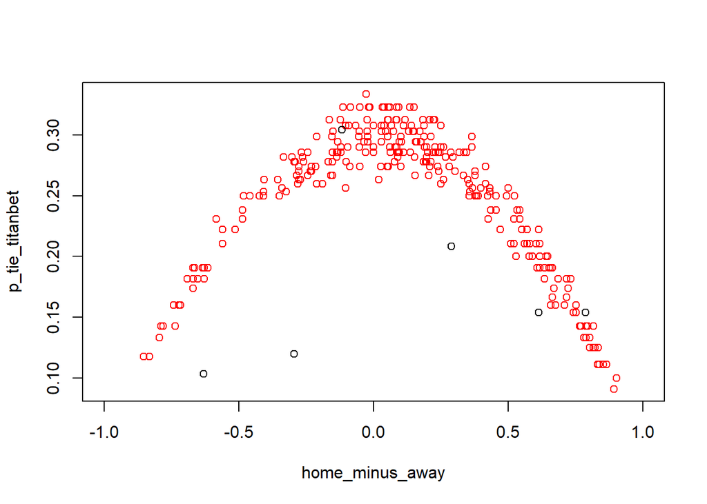

```r
bin_widths=summarise(group_by(titanbet_dt,bins,is_draw),count =n())

p_real_draw = c(0)

p_real_draw[1]<-bin_widths$count[2]/bin_widths$count[1]
p_real_draw[2]<-bin_widths$count[4]/bin_widths$count[3]
p_real_draw[3]<-bin_widths$count[6]/bin_widths$count[5]
p_real_draw[4]<-bin_widths$count[8]/bin_widths$count[7]
p_real_draw[5]<-bin_widths$count[10]/bin_widths$count[9]
p_real_draw[6]<-bin_widths$count[12]/bin_widths$count[11]
p_real_draw[7]<-bin_widths$count[14]/bin_widths$count[13]
p_real_draw[8]<-bin_widths$count[16]/bin_widths$count[15]
p_real_draw[9]<-bin_widths$count[18]/bin_widths$count[17]
p_real_draw[10]<-bin_widths$count[20]/bin_widths$count[19]

y = c((-0.853-0.408)/2, (-0.408-0.181)/2, (-0.181-0.0511)/2, (-0.0511+0.0552)/2, (0.0552+0.139)/2, (0.139+0.215)/2,
      (0.215+0.365)/2, (0.365+0.557)/2, (0.557+0.671)/2, (0.671+0.902)/2)

plot(home_minus_away, p_tie_titanbet, col="red",xlim = c(-1,1))
points(y, p_real_draw, col="black")
```

```r
# Bettings from ComeOn for home win, draw and away win
######################################################
home_win_comeon=filter(english_bets, variable=="odd_1"& odd_bookmakers=="ComeOn")
draw_comeon=filter(english_bets, variable=="odd_x"& odd_bookmakers=="ComeOn")
away_win_comeon=filter(english_bets, variable=="odd_2"& odd_bookmakers=="ComeOn")

p_home_comeon=1/home_win_comeon$value
p_tie_comeon=1/draw_comeon$value
p_away_comeon=1/away_win_comeon$value

p_normalized_home_comeon=1/home_win_comeon$value/(1/home_win_comeon$value+1/draw_comeon$value+1/away_win_comeon$value)
p_normalized_draw_comeon=1/draw_comeon$value/(1/home_win_comeon$value+1/draw_comeon$value+1/away_win_comeon$value)
p_normalized_away_comeon=1/away_win_comeon$value/(1/home_win_comeon$value+1/draw_comeon$value+1/away_win_comeon$value)


home_minus_away=p_home_comeon-p_away_comeon

comeon_dt = data.table(home_minus_away, matchids = draw_comeon$match_id, bins = discretize(home_minus_away,
                                                                                           breaks=10, right=TRUE, left=FALSE)
)

comeon_dt  = merge(comeon_dt, complete_english_matches_final, by.x = "matchids", by.y = "match_id")

comeon_dt= copy(comeon_dt)[,is_draw := english_match_results == 0]

summary(comeon_dt$bins)
```

```
##  [-0.818,-0.417]  (-0.417,-0.184] (-0.184,-0.0465] (-0.0465,0.0552]
##               30               29               29               31
##   (0.0552,0.141]    (0.141,0.221]    (0.221,0.362]    (0.362,0.552]
##               28               29               29               29
##    (0.552,0.671]    (0.671,0.886]
##               29               30
```

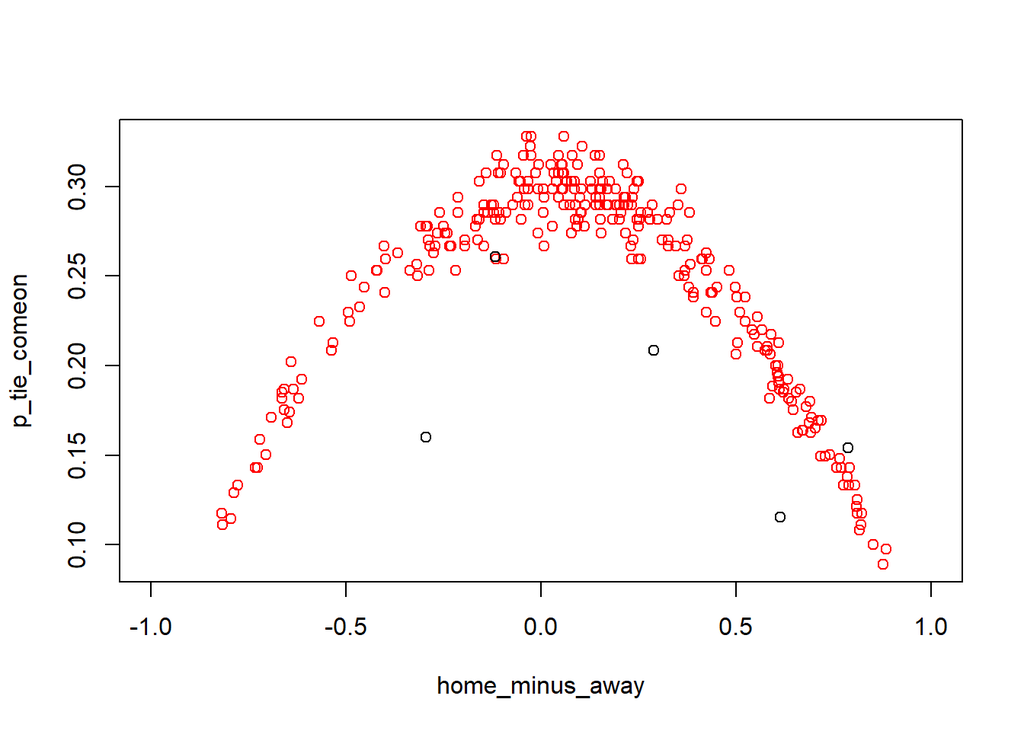

```r
bin_widths=summarise(group_by(comeon_dt,bins,is_draw),count =n())

p_real_draw = c(0)
p_real_draw[1]<-bin_widths$count[2]/bin_widths$count[1]
p_real_draw[2]<-bin_widths$count[4]/bin_widths$count[3]
p_real_draw[3]<-bin_widths$count[6]/bin_widths$count[5]
p_real_draw[4]<-bin_widths$count[8]/bin_widths$count[7]
p_real_draw[5]<-bin_widths$count[10]/bin_widths$count[9]
p_real_draw[6]<-bin_widths$count[12]/bin_widths$count[11]
p_real_draw[7]<-bin_widths$count[14]/bin_widths$count[13]
p_real_draw[8]<-bin_widths$count[16]/bin_widths$count[15]
p_real_draw[9]<-bin_widths$count[18]/bin_widths$count[17]
p_real_draw[10]<-bin_widths$count[20]/bin_widths$count[19]

y = c((-0.853-0.408)/2, (-0.408-0.181)/2, (-0.181-0.0511)/2, (-0.0511+0.0552)/2, (0.0552+0.139)/2, (0.139+0.215)/2,
      (0.215+0.365)/2, (0.365+0.557)/2, (0.557+0.671)/2, (0.671+0.902)/2)

plot(home_minus_away, p_tie_comeon, col="red",xlim = c(-1,1))
points(y, p_real_draw, col="black")
```

```r
# Bettings from Jetbull for home win, draw and away win
########################################################
home_win_jetbull=filter(english_bets, variable=="odd_1"& odd_bookmakers=="Jetbull")
draw_jetbull=filter(english_bets, variable=="odd_x"& odd_bookmakers=="Jetbull")
away_win_jetbull=filter(english_bets, variable=="odd_2"& odd_bookmakers=="Jetbull")

p_home_jetbull=1/home_win_jetbull$value
p_tie_jetbull=1/draw_jetbull$value
p_away_jetbull=1/away_win_jetbull$value

p_normalized_home_jetbull=1/home_win_jetbull$value/(1/home_win_jetbull$value+1/draw_jetbull$value+1/away_win_jetbull$value)
p_normalized_draw_jetbull=1/draw_jetbull$value/(1/home_win_jetbull$value+1/draw_jetbull$value+1/away_win_jetbull$value)
p_normalized_away_jetbull=1/away_win_jetbull$value/(1/home_win_jetbull$value+1/draw_jetbull$value+1/away_win_jetbull$value)

home_minus_away=p_home_jetbull-p_away_jetbull

jetbull_dt = data.table(home_minus_away, matchids = draw_jetbull$match_id, bins = discretize(home_minus_away,
                                                                                             breaks=10, right=TRUE, left=FALSE)
)

jetbull_dt  = merge(jetbull_dt, complete_english_matches_final, by.x = "matchids", by.y = "match_id")

jetbull_dt= copy(jetbull_dt)[,is_draw := english_match_results == 0]

summary(jetbull_dt$bins)
```

```
##  [-0.818,-0.403]   (-0.403,-0.17]  (-0.17,-0.0389] (-0.0389,0.0483]
##               30               29               30               29
##   (0.0483,0.131]    (0.131,0.215]    (0.215,0.349]    (0.349,0.538]
##               30               30               29               29
##    (0.538,0.668]    (0.668,0.887]
##               29               30
```

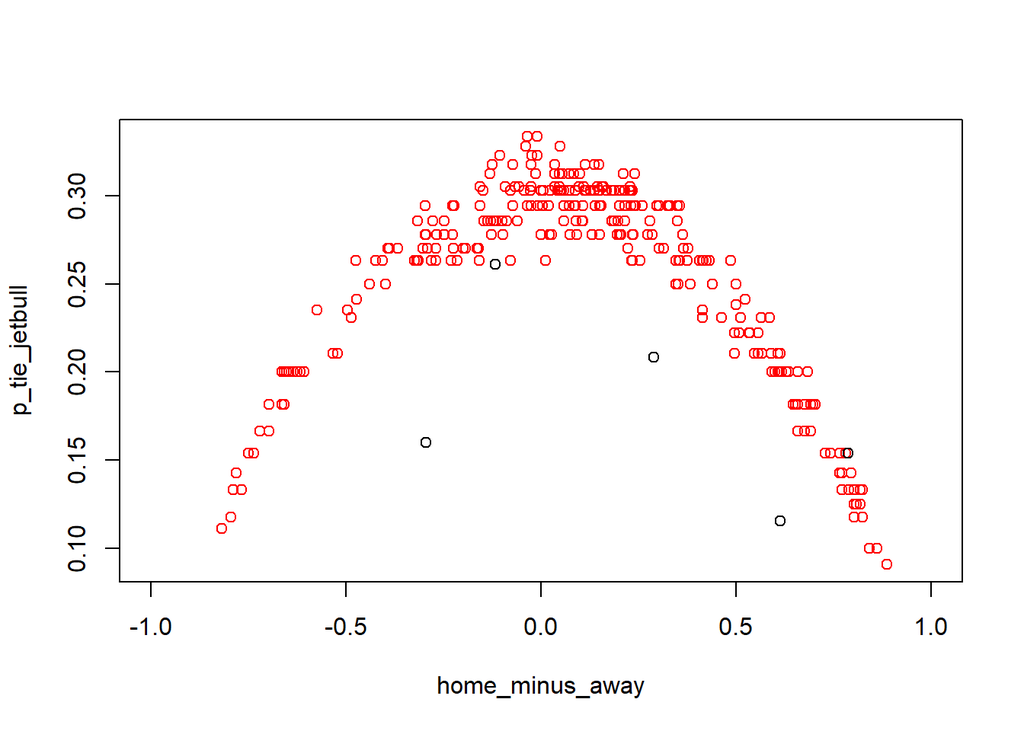

```r
bin_widths_c=summarise(group_by(jetbull_dt,bins,is_draw),count =n())

p_real_draw = c(0)
p_real_draw[1]<-bin_widths$count[2]/bin_widths$count[1]
p_real_draw[2]<-bin_widths$count[4]/bin_widths$count[3]
p_real_draw[3]<-bin_widths$count[6]/bin_widths$count[5]
p_real_draw[4]<-bin_widths$count[8]/bin_widths$count[7]
p_real_draw[5]<-bin_widths$count[10]/bin_widths$count[9]
p_real_draw[6]<-bin_widths$count[12]/bin_widths$count[11]
p_real_draw[7]<-bin_widths$count[14]/bin_widths$count[13]
p_real_draw[8]<-bin_widths$count[16]/bin_widths$count[15]
p_real_draw[9]<-bin_widths$count[18]/bin_widths$count[17]
p_real_draw[10]<-bin_widths$count[20]/bin_widths$count[19]

y = c((-0.853-0.408)/2, (-0.408-0.181)/2, (-0.181-0.0511)/2, (-0.0511+0.0552)/2, (0.0552+0.139)/2, (0.139+0.215)/2,
      (0.215+0.365)/2, (0.365+0.557)/2, (0.557+0.671)/2, (0.671+0.902)/2)

plot(home_minus_away, p_tie_jetbull, col="red",xlim = c(-1,1))
points(y, p_real_draw, col="black")
```

```r
# Bettings from NordicBet for home win, draw and away win
#########################################################
home_win_nordicbet=filter(english_bets, variable=="odd_1"& odd_bookmakers=="NordicBet")
draw_nordicbet=filter(english_bets, variable=="odd_x"& odd_bookmakers=="NordicBet")
away_win_nordicbet=filter(english_bets, variable=="odd_2"& odd_bookmakers=="NordicBet")

p_home_nordicbet=1/home_win_nordicbet$value
p_tie_nordicbet=1/draw_nordicbet$value
p_away_nordicbet=1/away_win_nordicbet$value

p_normalized_home_nordicbet=1/home_win_nordicbet$value/(1/home_win_nordicbet$value+1/draw_nordicbet$value+1/away_win_nordicbet$value)
p_normalized_draw_nordicbet=1/draw_nordicbet$value/(1/home_win_nordicbet$value+1/draw_nordicbet$value+1/away_win_nordicbet$value)
p_normalized_away_nordicbet=1/away_win_nordicbet$value/(1/home_win_nordicbet$value+1/draw_nordicbet$value+1/away_win_nordicbet$value)

home_minus_away=p_home_nordicbet-p_away_nordicbet

nordicbet_dt = data.table(home_minus_away, matchids = draw_nordicbet$match_id, bins = discretize(home_minus_away,
                                                                                                 breaks=10, right=TRUE, left=FALSE)
)

nordicbet_dt  = merge(nordicbet_dt, complete_english_matches_final, by.x = "matchids", by.y = "match_id")
nordicbet_dt= copy(nordicbet_dt)[,is_draw := english_match_results == 0]

summary(nordicbet_dt$bins)
```

```
##  [-0.834,-0.416]  (-0.416,-0.199] (-0.199,-0.0491] (-0.0491,0.0549]
##               29               29               30               28
##   (0.0549,0.134]    (0.134,0.214]    (0.214,0.353]     (0.353,0.54]
##               30               28               29               29
##     (0.54,0.664]    (0.664,0.884]
##               29               29
```

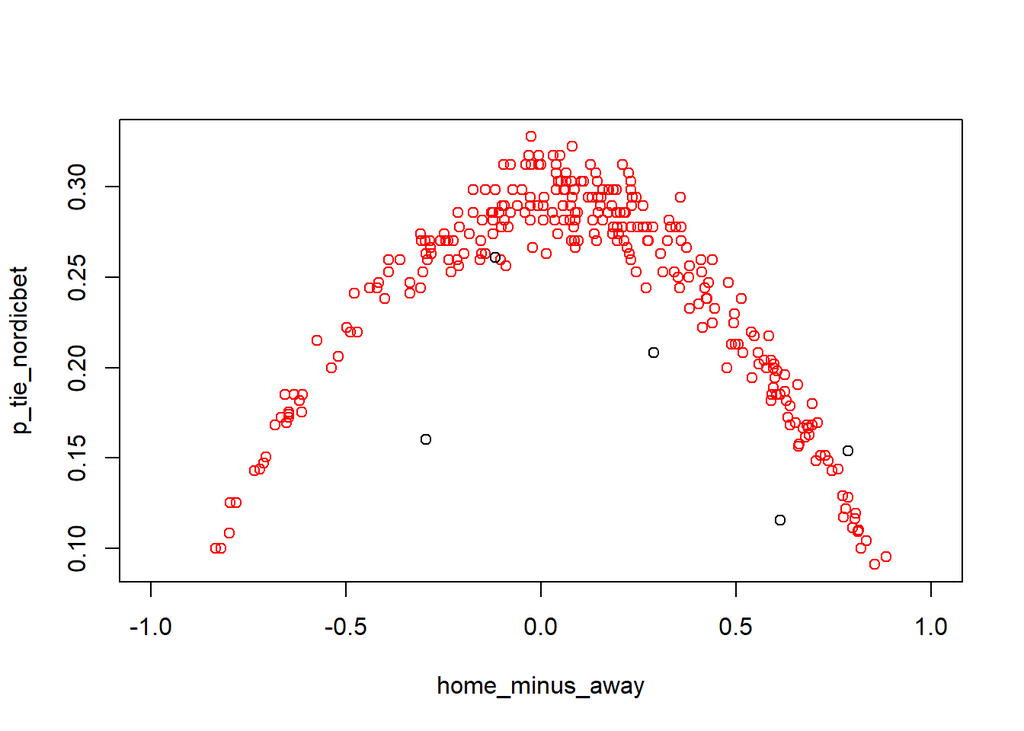

```r
bin_widths_c=summarise(group_by(nordicbet_dt,bins,is_draw),count =n())

p_real_draw = c(0)
p_real_draw[1]<-bin_widths$count[2]/bin_widths$count[1]
p_real_draw[2]<-bin_widths$count[4]/bin_widths$count[3]
p_real_draw[3]<-bin_widths$count[6]/bin_widths$count[5]
p_real_draw[4]<-bin_widths$count[8]/bin_widths$count[7]
p_real_draw[5]<-bin_widths$count[10]/bin_widths$count[9]
p_real_draw[6]<-bin_widths$count[12]/bin_widths$count[11]
p_real_draw[7]<-bin_widths$count[14]/bin_widths$count[13]
p_real_draw[8]<-bin_widths$count[16]/bin_widths$count[15]
p_real_draw[9]<-bin_widths$count[18]/bin_widths$count[17]
p_real_draw[10]<-bin_widths$count[20]/bin_widths$count[19]

y = c((-0.853-0.408)/2, (-0.408-0.181)/2, (-0.181-0.0511)/2, (-0.0511+0.0552)/2, (0.0552+0.139)/2, (0.139+0.215)/2,
      (0.215+0.365)/2, (0.365+0.557)/2, (0.557+0.671)/2, (0.671+0.902)/2)

plot(home_minus_away, p_tie_nordicbet, col="red",xlim = c(-1,1))
points(y, p_real_draw, col="black")
```

```r
# Bettings from 5Dimes for home win, draw and away win
#######################################################
home_win_5dimes=filter(english_bets, variable=="odd_1"& odd_bookmakers=="5Dimes")
draw_5dimes=filter(english_bets, variable=="odd_x"& odd_bookmakers=="5Dimes")
away_win_5dimes=filter(english_bets, variable=="odd_2"& odd_bookmakers=="5Dimes")

p_home_5dimes=1/home_win_5dimes$value
p_tie_5dimes=1/draw_5dimes$value
p_away_5dimes=1/away_win_5dimes$value

p_normalized_home_5dimes=1/home_win_5dimes$value/(1/home_win_5dimes$value+1/draw_5dimes$value+1/away_win_5dimes$value)
p_normalized_draw_5dimes=1/draw_5dimes$value/(1/home_win_5dimes$value+1/draw_5dimes$value+1/away_win_5dimes$value)
p_normalized_away_5dimes=1/away_win_5dimes$value/(1/home_win_5dimes$value+1/draw_5dimes$value+1/away_win_5dimes$value)

home_minus_away=p_home_5dimes-p_away_5dimes

dimes_dt = data.table(home_minus_away, matchids = draw_5dimes$match_id, bins = discretize(home_minus_away,
                                                                                          breaks=10, right=TRUE, left=FALSE)
)

dimes_dt  = merge(dimes_dt, complete_english_matches_final, by.x = "matchids", by.y = "match_id")

dimes_dt= copy(dimes_dt)[,is_draw := english_match_results == 0]

summary(dimes_dt$bins)
```

```
##  [-0.777,-0.491]  (-0.491,-0.295] (-0.295,-0.0621] (-0.0621,0.0417]
##               11               10               11               10
##   (0.0417,0.107]     (0.107,0.22]     (0.22,0.365]     (0.365,0.59]
##               11               10               10               11
##     (0.59,0.684]    (0.684,0.882]
##               10               11
```

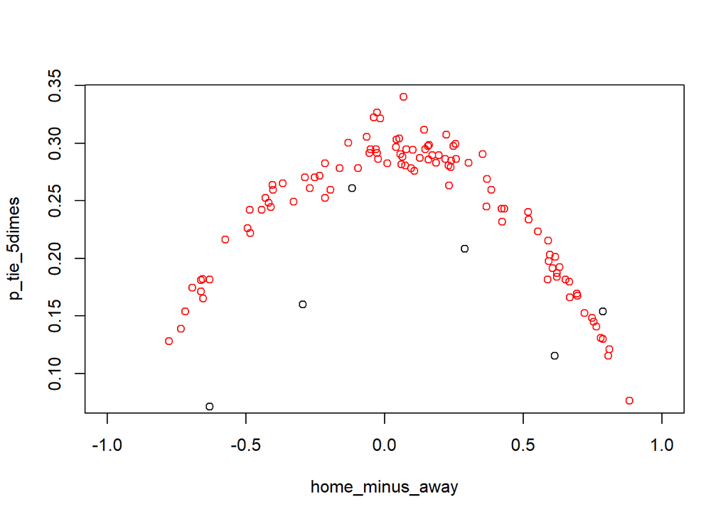

```r
bin_widths_c=summarise(group_by(dimes_dt,bins,is_draw),count =n())

p_real_draw = c(0)
p_real_draw[1]<-bin_widths$count[2]/bin_widths$count[1]
p_real_draw[2]<-bin_widths$count[4]/bin_widths$count[3]
p_real_draw[3]<-bin_widths$count[6]/bin_widths$count[5]
p_real_draw[4]<-bin_widths$count[8]/bin_widths$count[7]
p_real_draw[5]<-bin_widths$count[10]/bin_widths$count[9]
p_real_draw[6]<-bin_widths$count[12]/bin_widths$count[11]
p_real_draw[7]<-bin_widths$count[14]/bin_widths$count[13]
p_real_draw[8]<-bin_widths$count[16]/bin_widths$count[15]
p_real_draw[9]<-bin_widths$count[18]/bin_widths$count[17]
p_real_draw[10]<-bin_widths$count[20]/bin_widths$count[19]

y = c((-0.853-0.408)/2, (-0.408-0.181)/2, (-0.181-0.0511)/2, (-0.0511+0.0552)/2, (0.0552+0.139)/2, (0.139+0.215)/2,
      (0.215+0.365)/2, (0.365+0.557)/2, (0.557+0.671)/2, (0.671+0.902)/2)


plot(home_minus_away, p_tie_5dimes, col="red",xlim = c(-1,1))
points(y, p_real_draw, col="black")
```

```r
######task 3#####

#Selecting English Premier League data with league id of 148 and taking only played matches and reducing bias

matches_extra<-complete_english_matches[!is.na(english_matches$match_hometeam_extra_score), ]
matches_noextra<-complete_english_matches[is.na(english_matches$match_hometeam_extra_score), ]
matches_noextra<-matches_noextra %>%  select(match_id,match_hometeam_score, match_awayteam_score, match_hometeam_extra_score, match_awayteam_extra_score)
matches_extra<-matches_extra %>%  select(match_id,match_hometeam_score, match_awayteam_score, match_hometeam_extra_score, match_awayteam_extra_score)

matches_extra$match_result<-matches_extra$match_hometeam_score-matches_extra$match_awayteam_score
matches_extra$extratime_result<-matches_extra$match_hometeam_extra_score-matches_extra$match_awayteam_extra_score
matches_extra$normaltime_result<-matches_extra$match_result+matches_extra$extratime_result

for (i in 1:length(matches_extra$match_result)){
   if (matches_extra$match_result[i]>0){
      matches_extra$match_result_status[i]<-c('home_win')
   }
   else if (matches_extra$match_result[i]==0){
      matches_extra$match_result_status[i]<-c('draw')
   }
   else {
      matches_extra$match_result_status[i]<-c('away_win')
   }
}

for (i in 1:length(matches_extra$match_result)){
   if (matches_extra$normaltime_result[i]>0){
      matches_extra$normaltime_result_status[i]<-c('home_win')
   }
   else if (matches_extra$normaltime_result[i]==0){
      matches_extra$normaltime_result_status[i]<-c('draw')
   }
   else {
      matches_extra$normaltime_result_status[i]<-c('away_win')
   }
}

for (i in 1:length(matches_extra$match_result)){
   if (matches_extra$normaltime_result_status[i] ==  matches_extra$match_result_status[i]){
      matches_extra$bias[i]<-c('No')
   }
   else {
      matches_extra$bias[i]<-c('Yes')
   }
}

matches_extra_reduced<-c(0)
matches_extra_reduced=filter(matches_extra, bias=="No")
matches_extra_reduced<-matches_extra_reduced%>%  select(match_id,match_hometeam_score, match_awayteam_score, match_hometeam_extra_score, match_awayteam_extra_score)

final_matches_noextra<-rbind(matches_extra_reduced, matches_noextra)

#43 matches are removed because there are goals in the extra time that changed the winning side

match_ids<- final_matches_noextra$match_id
#there are 760 bookings in premier league
english_bookings=booking[booking$match_id %in% match_ids, ]
#Only 22 of them are red cards
english_booking_red<-filter(english_bookings, card=="red card")
#the red cards in the first 15 min eliminated, there is only one match
english_booking_red_first<-c(0,0,0,0,0)
english_booking_red_first <- english_booking_red[!english_booking_red$time==4, ]

# Real match results

final_matches_noextra$match_result<-final_matches_noextra$match_hometeam_score-final_matches_noextra$match_awayteam_score

#The bets are reduced for only English Premier League with filtering thourough match ids

english_matches_ids <- final_matches_noextra$match_id
english_bets=bets[bets$match_id %in% english_matches_ids, ]


# Bettings from Titanbet for home win, draw and away win
########################################################
home_win_titanbet=filter(english_bets, variable=="odd_1"& odd_bookmakers=="Titanbet")
draw_titanbet=filter(english_bets, variable=="odd_x"& odd_bookmakers=="Titanbet")
away_win_titanbet=filter(english_bets, variable=="odd_2"& odd_bookmakers=="Titanbet")

p_home_titanbet=1/home_win_titanbet$value
p_tie_titanbet=1/draw_titanbet$value
p_away_titanbet=1/away_win_titanbet$value

p_normalized_home_titanbet=(1/home_win_titanbet$value)/(1/home_win_titanbet$value+1/draw_titanbet$value+1/away_win_titanbet$value)
p_normalized_draw_titanbet=(1/draw_titanbet$value)/(1/home_win_titanbet$value+1/draw_titanbet$value+1/away_win_titanbet$value)
p_normalized_away_titanbet=(1/away_win_titanbet$value)/(1/home_win_titanbet$value+1/draw_titanbet$value+1/away_win_titanbet$value)

home_minus_away=p_home_titanbet-p_away_titanbet

titanbet_dt = data.table(home_minus_away, matchids = draw_titanbet$match_id, bins = discretize(home_minus_away,
                                                                                               breaks=10, right=TRUE, left=FALSE)
)

titanbet_dt  = merge(titanbet_dt, complete_english_matches_final, by.x = "matchids", by.y = "match_id")

titanbet_dt= copy(titanbet_dt)[,is_draw := english_match_results == 0]

summary(titanbet_dt$bins)
```

```
##  [-0.853,-0.452]  (-0.452,-0.202] (-0.202,-0.0504] (-0.0504,0.0552]
##               27               26               26               26
##   (0.0552,0.141]    (0.141,0.228]    (0.228,0.379]    (0.379,0.571]
##               27               26               26               27
##    (0.571,0.715]    (0.715,0.902]
##               25               27
```

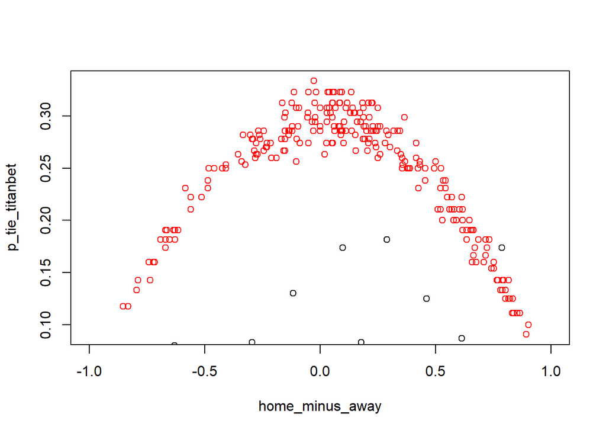

```r
bin_widths=summarise(group_by(titanbet_dt,bins,is_draw),count =n())

p_real_draw = c(0)

p_real_draw[1]<-bin_widths$count[2]/bin_widths$count[1]
p_real_draw[2]<-bin_widths$count[4]/bin_widths$count[3]
p_real_draw[3]<-bin_widths$count[6]/bin_widths$count[5]
p_real_draw[4]<-bin_widths$count[8]/bin_widths$count[7]
p_real_draw[5]<-bin_widths$count[10]/bin_widths$count[9]
p_real_draw[6]<-bin_widths$count[12]/bin_widths$count[11]
p_real_draw[7]<-bin_widths$count[14]/bin_widths$count[13]
p_real_draw[8]<-bin_widths$count[16]/bin_widths$count[15]
p_real_draw[9]<-bin_widths$count[18]/bin_widths$count[17]
p_real_draw[10]<-bin_widths$count[20]/bin_widths$count[19]

y = c((-0.853-0.408)/2, (-0.408-0.181)/2, (-0.181-0.0511)/2, (-0.0511+0.0552)/2, (0.0552+0.139)/2, (0.139+0.215)/2,
      (0.215+0.365)/2, (0.365+0.557)/2, (0.557+0.671)/2, (0.671+0.902)/2)

plot(home_minus_away, p_tie_titanbet, col="red",xlim = c(-1,1))
points(y, p_real_draw, col="black")
```

```r
# Bettings from ComeOn for home win, draw and away win
######################################################
home_win_comeon=filter(english_bets, variable=="odd_1"& odd_bookmakers=="ComeOn")
draw_comeon=filter(english_bets, variable=="odd_x"& odd_bookmakers=="ComeOn")
away_win_comeon=filter(english_bets, variable=="odd_2"& odd_bookmakers=="ComeOn")

p_home_comeon=1/home_win_comeon$value
p_tie_comeon=1/draw_comeon$value
p_away_comeon=1/away_win_comeon$value

p_normalized_home_comeon=1/home_win_comeon$value/(1/home_win_comeon$value+1/draw_comeon$value+1/away_win_comeon$value)
p_normalized_draw_comeon=1/draw_comeon$value/(1/home_win_comeon$value+1/draw_comeon$value+1/away_win_comeon$value)
p_normalized_away_comeon=1/away_win_comeon$value/(1/home_win_comeon$value+1/draw_comeon$value+1/away_win_comeon$value)


home_minus_away=p_home_comeon-p_away_comeon

comeon_dt = data.table(home_minus_away, matchids = draw_comeon$match_id, bins = discretize(home_minus_away,
                                                                                           breaks=10, right=TRUE, left=FALSE)
)

comeon_dt  = merge(comeon_dt, complete_english_matches_final, by.x = "matchids", by.y = "match_id")

comeon_dt= copy(comeon_dt)[,is_draw := english_match_results == 0]

summary(comeon_dt$bins)
```

```
##  [-0.818,-0.454]  (-0.454,-0.195] (-0.195,-0.0459] (-0.0459,0.0552]
##               26               27               25               28
##   (0.0552,0.141]    (0.141,0.234]    (0.234,0.372]     (0.372,0.58]
##               24               26               26               26
##      (0.58,0.69]     (0.69,0.886]
##               26               26
```

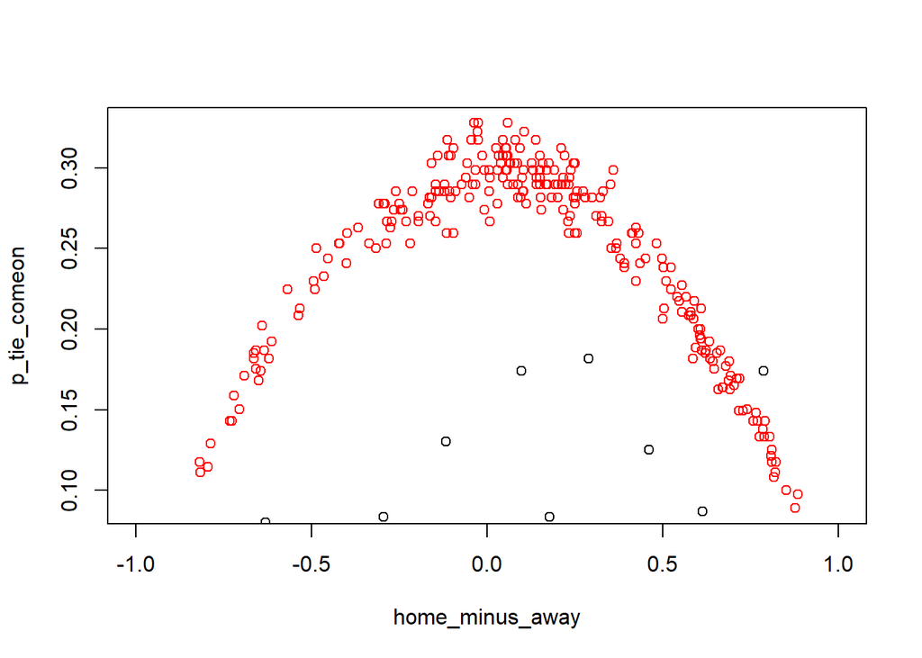

```r
bin_widths_c=summarise(group_by(comeon_dt,bins,is_draw),count =n())

p_real_draw = c(0)
p_real_draw[1]<-bin_widths$count[2]/bin_widths$count[1]
p_real_draw[2]<-bin_widths$count[4]/bin_widths$count[3]
p_real_draw[3]<-bin_widths$count[6]/bin_widths$count[5]
p_real_draw[4]<-bin_widths$count[8]/bin_widths$count[7]
p_real_draw[5]<-bin_widths$count[10]/bin_widths$count[9]
p_real_draw[6]<-bin_widths$count[12]/bin_widths$count[11]
p_real_draw[7]<-bin_widths$count[14]/bin_widths$count[13]
p_real_draw[8]<-bin_widths$count[16]/bin_widths$count[15]
p_real_draw[9]<-bin_widths$count[18]/bin_widths$count[17]
p_real_draw[10]<-bin_widths$count[20]/bin_widths$count[19]

y = c((-0.853-0.408)/2, (-0.408-0.181)/2, (-0.181-0.0511)/2, (-0.0511+0.0552)/2, (0.0552+0.139)/2, (0.139+0.215)/2,
      (0.215+0.365)/2, (0.365+0.557)/2, (0.557+0.671)/2, (0.671+0.902)/2)

plot(home_minus_away, p_tie_comeon, col="red",xlim = c(-1,1))
points(y, p_real_draw, col="black")
```

```r
# Bettings from Jetbull for home win, draw and away win
########################################################
home_win_jetbull=filter(english_bets, variable=="odd_1"& odd_bookmakers=="Jetbull")
draw_jetbull=filter(english_bets, variable=="odd_x"& odd_bookmakers=="Jetbull")
away_win_jetbull=filter(english_bets, variable=="odd_2"& odd_bookmakers=="Jetbull")

p_home_jetbull=1/home_win_jetbull$value
p_tie_jetbull=1/draw_jetbull$value
p_away_jetbull=1/away_win_jetbull$value

p_normalized_home_jetbull=1/home_win_jetbull$value/(1/home_win_jetbull$value+1/draw_jetbull$value+1/away_win_jetbull$value)
p_normalized_draw_jetbull=1/draw_jetbull$value/(1/home_win_jetbull$value+1/draw_jetbull$value+1/away_win_jetbull$value)
p_normalized_away_jetbull=1/away_win_jetbull$value/(1/home_win_jetbull$value+1/draw_jetbull$value+1/away_win_jetbull$value)

home_minus_away=p_home_jetbull-p_away_jetbull

jetbull_dt = data.table(home_minus_away, matchids = draw_jetbull$match_id, bins = discretize(home_minus_away,
                                                                                             breaks=10, right=TRUE, left=FALSE)
)

jetbull_dt  = merge(jetbull_dt, complete_english_matches_final, by.x = "matchids", by.y = "match_id")

jetbull_dt= copy(jetbull_dt)[,is_draw := english_match_results == 0]

summary(jetbull_dt$bins)
```

```
##  [-0.818,-0.439]  (-0.439,-0.193] (-0.193,-0.0354] (-0.0354,0.0489]
##               27               26               26               27
##   (0.0489,0.137]     (0.137,0.23]     (0.23,0.356]    (0.356,0.566]
##               26               25               26               27
##    (0.566,0.692]    (0.692,0.887]
##               28               23
```

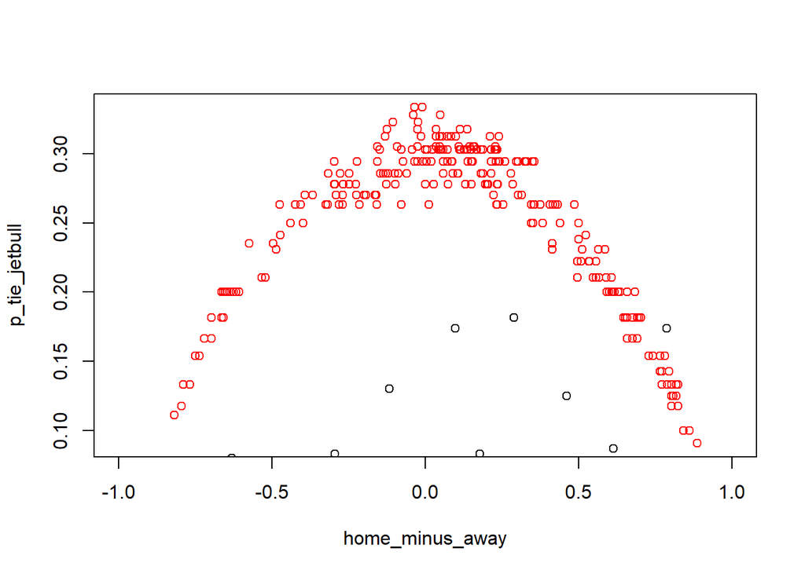

```r
bin_widths_c=summarise(group_by(jetbull_dt,bins,is_draw),count =n())

p_real_draw = c(0)
p_real_draw[1]<-bin_widths$count[2]/bin_widths$count[1]
p_real_draw[2]<-bin_widths$count[4]/bin_widths$count[3]
p_real_draw[3]<-bin_widths$count[6]/bin_widths$count[5]
p_real_draw[4]<-bin_widths$count[8]/bin_widths$count[7]
p_real_draw[5]<-bin_widths$count[10]/bin_widths$count[9]
p_real_draw[6]<-bin_widths$count[12]/bin_widths$count[11]
p_real_draw[7]<-bin_widths$count[14]/bin_widths$count[13]
p_real_draw[8]<-bin_widths$count[16]/bin_widths$count[15]
p_real_draw[9]<-bin_widths$count[18]/bin_widths$count[17]
p_real_draw[10]<-bin_widths$count[20]/bin_widths$count[19]

y = c((-0.853-0.408)/2, (-0.408-0.181)/2, (-0.181-0.0511)/2, (-0.0511+0.0552)/2, (0.0552+0.139)/2, (0.139+0.215)/2,
      (0.215+0.365)/2, (0.365+0.557)/2, (0.557+0.671)/2, (0.671+0.902)/2)

plot(home_minus_away, p_tie_jetbull, col="red",xlim = c(-1,1))
points(y, p_real_draw, col="black")
```

```r
# Bettings from NordicBet for home win, draw and away win
#########################################################
home_win_nordicbet=filter(english_bets, variable=="odd_1"& odd_bookmakers=="NordicBet")
draw_nordicbet=filter(english_bets, variable=="odd_x"& odd_bookmakers=="NordicBet")
away_win_nordicbet=filter(english_bets, variable=="odd_2"& odd_bookmakers=="NordicBet")

p_home_nordicbet=1/home_win_nordicbet$value
p_tie_nordicbet=1/draw_nordicbet$value
p_away_nordicbet=1/away_win_nordicbet$value

p_normalized_home_nordicbet=1/home_win_nordicbet$value/(1/home_win_nordicbet$value+1/draw_nordicbet$value+1/away_win_nordicbet$value)
p_normalized_draw_nordicbet=1/draw_nordicbet$value/(1/home_win_nordicbet$value+1/draw_nordicbet$value+1/away_win_nordicbet$value)
p_normalized_away_nordicbet=1/away_win_nordicbet$value/(1/home_win_nordicbet$value+1/draw_nordicbet$value+1/away_win_nordicbet$value)

home_minus_away=p_home_nordicbet-p_away_nordicbet

nordicbet_dt = data.table(home_minus_away, matchids = draw_nordicbet$match_id, bins = discretize(home_minus_away,
                                                                                                 breaks=10, right=TRUE, left=FALSE)
)

nordicbet_dt  = merge(nordicbet_dt, complete_english_matches_final, by.x = "matchids", by.y = "match_id")
nordicbet_dt= copy(nordicbet_dt)[,is_draw := english_match_results == 0]

summary(nordicbet_dt$bins)
```

```
##  [-0.834,-0.451]  (-0.451,-0.207] (-0.207,-0.0428] (-0.0428,0.0537]
##               26               26               25               26
##   (0.0537,0.134]    (0.134,0.226]    (0.226,0.364]     (0.364,0.57]
##               26               25               26               25
##     (0.57,0.684]    (0.684,0.884]
##               26               26
```

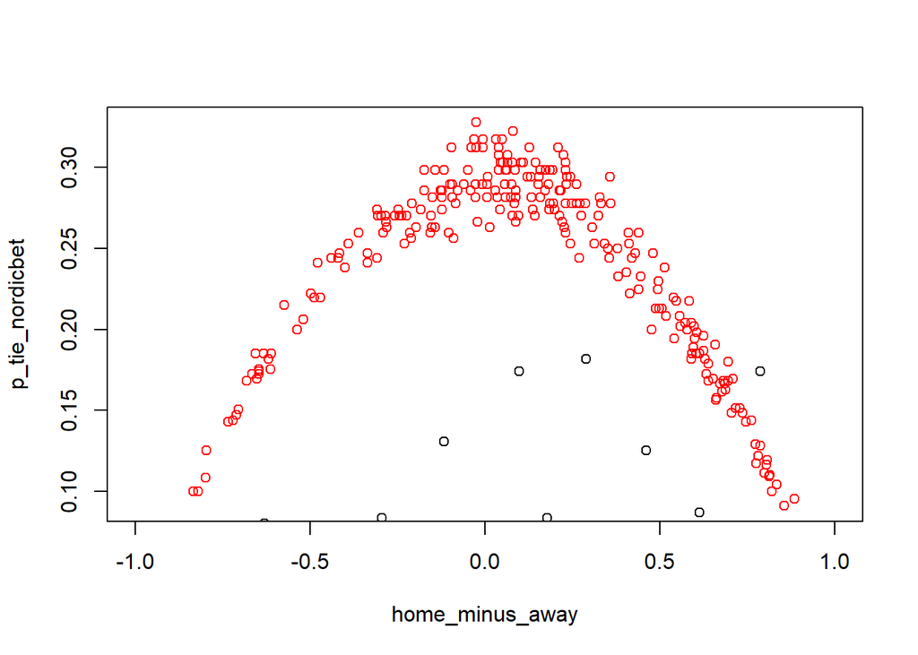

```r
bin_widths_c=summarise(group_by(nordicbet_dt,bins,is_draw),count =n())

p_real_draw = c(0)
p_real_draw[1]<-bin_widths$count[2]/bin_widths$count[1]
p_real_draw[2]<-bin_widths$count[4]/bin_widths$count[3]
p_real_draw[3]<-bin_widths$count[6]/bin_widths$count[5]
p_real_draw[4]<-bin_widths$count[8]/bin_widths$count[7]
p_real_draw[5]<-bin_widths$count[10]/bin_widths$count[9]
p_real_draw[6]<-bin_widths$count[12]/bin_widths$count[11]
p_real_draw[7]<-bin_widths$count[14]/bin_widths$count[13]
p_real_draw[8]<-bin_widths$count[16]/bin_widths$count[15]
p_real_draw[9]<-bin_widths$count[18]/bin_widths$count[17]
p_real_draw[10]<-bin_widths$count[20]/bin_widths$count[19]

y = c((-0.853-0.408)/2, (-0.408-0.181)/2, (-0.181-0.0511)/2, (-0.0511+0.0552)/2, (0.0552+0.139)/2, (0.139+0.215)/2,
      (0.215+0.365)/2, (0.365+0.557)/2, (0.557+0.671)/2, (0.671+0.902)/2)

plot(home_minus_away, p_tie_nordicbet, col="red",xlim = c(-1,1))
points(y, p_real_draw, col="black")
```

```r
# Bettings from 5Dimes for home win, draw and away win
#######################################################
home_win_5dimes=filter(english_bets, variable=="odd_1"& odd_bookmakers=="5Dimes")
draw_5dimes=filter(english_bets, variable=="odd_x"& odd_bookmakers=="5Dimes")
away_win_5dimes=filter(english_bets, variable=="odd_2"& odd_bookmakers=="5Dimes")

p_home_5dimes=1/home_win_5dimes$value
p_tie_5dimes=1/draw_5dimes$value
p_away_5dimes=1/away_win_5dimes$value

p_normalized_home_5dimes=1/home_win_5dimes$value/(1/home_win_5dimes$value+1/draw_5dimes$value+1/away_win_5dimes$value)
p_normalized_draw_5dimes=1/draw_5dimes$value/(1/home_win_5dimes$value+1/draw_5dimes$value+1/away_win_5dimes$value)
p_normalized_away_5dimes=1/away_win_5dimes$value/(1/home_win_5dimes$value+1/draw_5dimes$value+1/away_win_5dimes$value)

home_minus_away=p_home_5dimes-p_away_5dimes

dimes_dt = data.table(home_minus_away, matchids = draw_5dimes$match_id, bins = discretize(home_minus_away,
                                                                                          breaks=10, right=TRUE, left=FALSE)
)

dimes_dt  = merge(dimes_dt, complete_english_matches_final, by.x = "matchids", by.y = "match_id")

dimes_dt= copy(dimes_dt)[,is_draw := english_match_results == 0]

summary(dimes_dt$bins)
```

```
##  [-0.735,-0.492]  (-0.492,-0.304] (-0.304,-0.0993] (-0.0993,0.0446]
##               10                9                9               10
##   (0.0446,0.118]    (0.118,0.229]    (0.229,0.373]      (0.373,0.6]
##                9                9               10                9
##      (0.6,0.695]    (0.695,0.882]
##                9               10
```

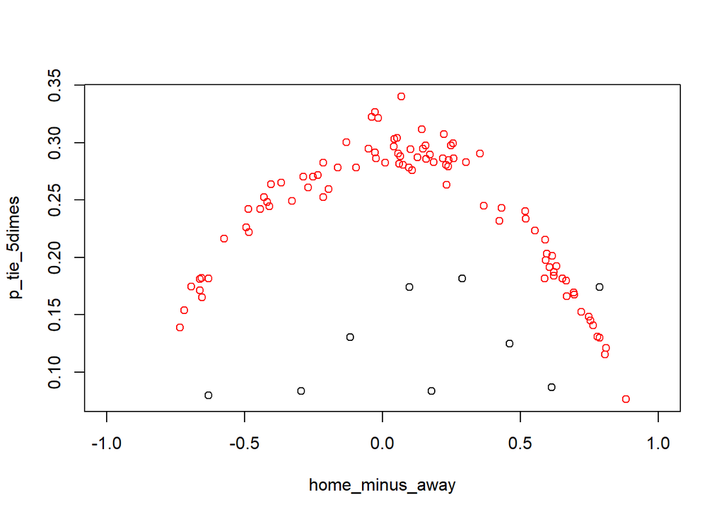

```r
bin_widths_c=summarise(group_by(dimes_dt,bins,is_draw),count =n())

p_real_draw = c(0)
p_real_draw[1]<-bin_widths$count[2]/bin_widths$count[1]
p_real_draw[2]<-bin_widths$count[4]/bin_widths$count[3]
p_real_draw[3]<-bin_widths$count[6]/bin_widths$count[5]
p_real_draw[4]<-bin_widths$count[8]/bin_widths$count[7]
p_real_draw[5]<-bin_widths$count[10]/bin_widths$count[9]
p_real_draw[6]<-bin_widths$count[12]/bin_widths$count[11]
p_real_draw[7]<-bin_widths$count[14]/bin_widths$count[13]
p_real_draw[8]<-bin_widths$count[16]/bin_widths$count[15]
p_real_draw[9]<-bin_widths$count[18]/bin_widths$count[17]
p_real_draw[10]<-bin_widths$count[20]/bin_widths$count[19]

y = c((-0.853-0.408)/2, (-0.408-0.181)/2, (-0.181-0.0511)/2, (-0.0511+0.0552)/2, (0.0552+0.139)/2, (0.139+0.215)/2,
      (0.215+0.365)/2, (0.365+0.557)/2, (0.557+0.671)/2, (0.671+0.902)/2)


plot(home_minus_away, p_tie_5dimes, col="red",xlim = c(-1,1))
points(y, p_real_draw, col="black")
```